# Methodology

## 6.1. Logistic regression

If we want to estimate the p parameter (probability) from a binomial model $k|N \sim Binomial(p)$, where p is redefined as a process model, for example $p = \beta_0 + \beta_1 X$, then we would like the p estimates for different values of predictor(s) X to be bounded by 0 and 1 (the probability scale). There are many functions that behave like this, but it is the logistic function that is mostly used in regression models.

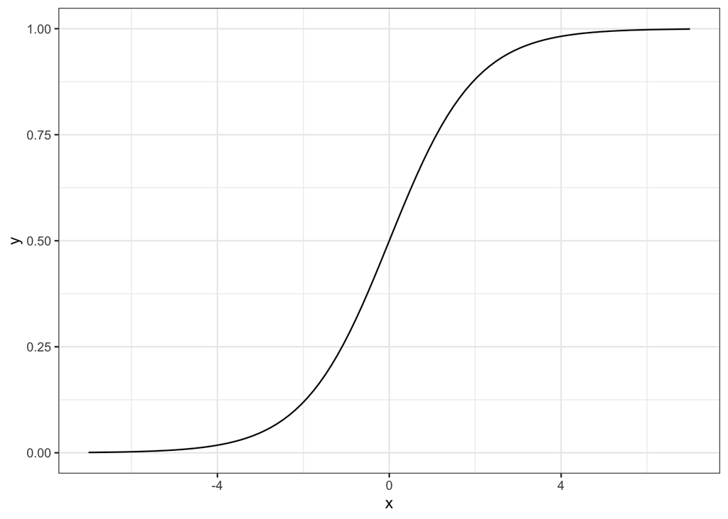

```r
x <- seq(-7,7, length.out = 100)
y <- exp(x) / (1+exp(x))
ggplot(data=NULL, aes(x,y))+ geom_line()+ theme_bw()
```

In this curve the slope first gradually increases until the mid-point (at x=0, y=0.5), where it achieves its maximum value, and then starts to decrease again.

In logistic regression with binomial data model (likelihood) the Y-data are the number of “successes” (k) and the the number of tries (N), but what we actually estimate is not k, but the probability of success, conditional on the predictors X, or $P(Y=1 \vert X)$.

$P(Y = 1 \vert X)$ means “probability of Y = 1 (for example, that the predicted value is”Male” == 1) given a particular X-predictor value (or a set of values for different X-predictors).

To achieve estimation in the probability scale, we are not transforming the data, but the model structure itself. We start with the logistic transformation, which for the simple linear function $y = P(Y = 1 \vert X) = \beta_0 + \beta_1x$ is

$$P(Y = 1 \vert X) =\frac{exp(\beta_0 + \beta_1x)}{1 + exp(\beta_0 + \beta_1x)}$$

$exp(a)$ means $e^a$, where $e$ is the Euler number, or the number whose natural logarithm is 1 ($e$ is the base of the natural logarithm). $e$ is about 2.71828 and we get it from the equation $(1 + 1/n)^n$, if n approaches infinity.

In any case, when using the logit-transformation we model the dependence of y-value on x-values as a straight line. In the probability scale our prediction becomes the S-shaped logistic curve.

The logit of probability p, logit(p), equals log(odds):

$$logit(p)=\log \left({\frac {p}{1-p}}\right)=\log(p)-\log(1-p)$$

The probabilities, the odds and the log-odds relate to each other like this:

```
## # A tibble: 11 × 3
##        p    odds log_odds
##    <dbl>   <dbl>    <dbl>
##  1   0     0     -Inf
##  2   0.1   0.111   -2.20
##  3   0.2   0.25    -1.39
##  4   0.3   0.429   -0.847
##  5   0.4   0.667   -0.405
##  6   0.5   1        0
##  7   0.6   1.5      0.405
##  8   0.7   2.33     0.847
##  9   0.8   4        1.39
## 10   0.9   9        2.20
## 11   1   Inf      Inf
```

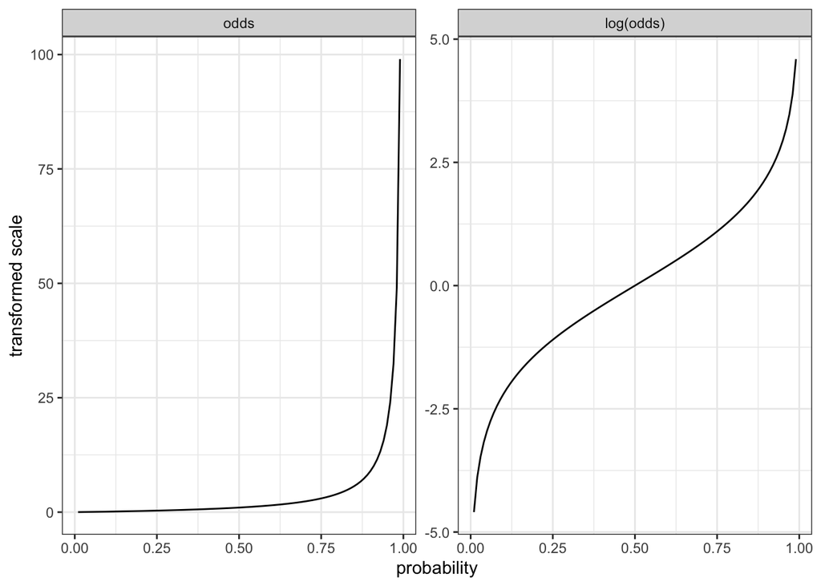

For the non-transformed process model $y = \beta_0 + \beta_1x$ the odds equals the exponent from fitted linear model:

$$odds= \frac {P(Y = 1 ~\vert~ X)}{1-P(Y = 1 ~\vert~ X)} = exp(\beta_0+\beta_1x)$$

and equivalently

$$log(odds) = logit(p) = \beta_0 + \beta_1x$$

With the simple process model, the interpretation of the $\beta_1$ coefficient is that when we increase the X-variable by one unit, then the log odds increase by $\beta_1$ units, and odds increase by $exp(\beta_1)$ units. Note that $\beta_1$ does not correspond to any fixed rate of change in $P(Y = 1 \vert X)$. This rate depends on the value of X. Still, as long as $\beta_1 > 0$, the $P(Y = 1)$ is guaranteed to increase in response to any increase in X (and vice versa).

When we subtract the log-odds of two probabilities, we get the logarithm of the odds ratio:

$${log} (OR)= {logit} (p_{1})- {logit} (p_{2})$$

**Odds-ratio**

We have a drug vs placebo experiment with binary outcome (alive/dead). Thrn

- a - drug/alive nr of cases,
- b - drug/dead nr of cases,
- c - placebo/alive nr of cases,
- d - placebo/dead nr of cases.

$$OR = \frac {a/b}{c/d}$$

- OR = 1 Drug has no effect on the odds of the outcome (being alive)
- OR > 1 Drug increases the odds of being alive
- OR < 1 Drug decreases the odds of being alive

Logistic regression generalizes the odds ratio beyond two binary variables. When we have a binary Y-variable and binary $X_1$-variable (drug vs placebo) and a set of other predictors ($X_2...X_n$), then the $\beta_1$ coefficient for $X_1$ is connected with conditional OR. $\exp(\beta_1)$ gives the odds ratio of Y for the two $X_1$ values, given that all other predictors are fixed (this is the usual interpretation of independent linear regression slopes).

## 6.2. Code examples

We have a drug candidate study with two groups, 350 subjects in each.

- 273 subjects out of 350, who got the drug candidate, recovered from the disease.
- 289 out of 350, who got the placebo, recovered.

Does the drug work?

Calculating simple fractions shows that with the drug 78% of subjects survived and with placebo 82% survived, indicating that the drug is less than useful. We next fit a model akin to Fisher’s exact test or chi-square test in traditional statistics.

The model structure is:

$$y_i \sim Binomial(n, p)$$
$$logit(p) = \beta_0 + \beta_1x_i$$
$$\beta_0, \beta_1 \sim N(0,1)$$

where the first row is the data model (likelihood), the second row re-defines the single parameter p of the binomial distribution as logit-transformed and substitutes it with a linear model with 2 parameters. The third row gives identical normal priors for these parameters. In the model y corresponds to the vector of k values at both drug and placebo conditions, and x corresponds to the “drug” variable with two levels (0 for the placebo condition and 1 for the drug condition). The index *i* indicates that the model sees individual y and x values in pairs, as defined by the row index *i*. This way we can use individual x-values to predict the corresponding y-values.

```r
d1 <- tibble(k= c(273,289), N=c(350, 350),
             drug=c("1", "0"))

m_d1.1 <- brm(k|trials(N)~drug,
              data = d1,

              family = binomial(),
              # link="logit" is the default for the binomial family.

              prior = prior(normal(0,1), class="b"),

              file = "models/m_d1.1")

posterior_summary(m_d1.1)[-3,]
```

```
##               Estimate Est.Error       Q2.5      Q97.5
## b_Intercept  1.5597475 0.1404037  1.2875077 1.83013985
## b_drug1     -0.2941516 0.1893265 -0.6647871 0.07680444
```

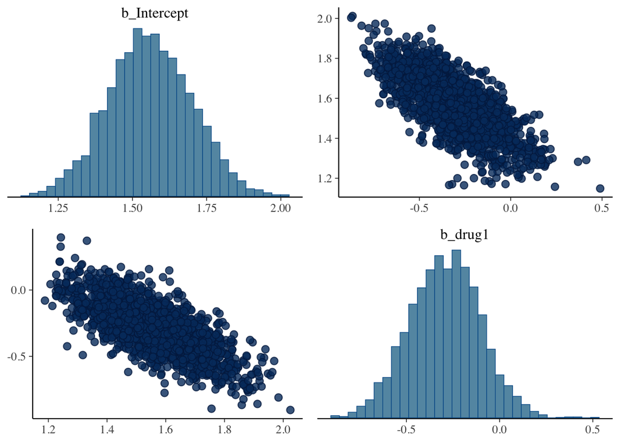

```r
pairs(m_d1.1)
```

The model predictions for the surviving fractions of subjects under both conditions:

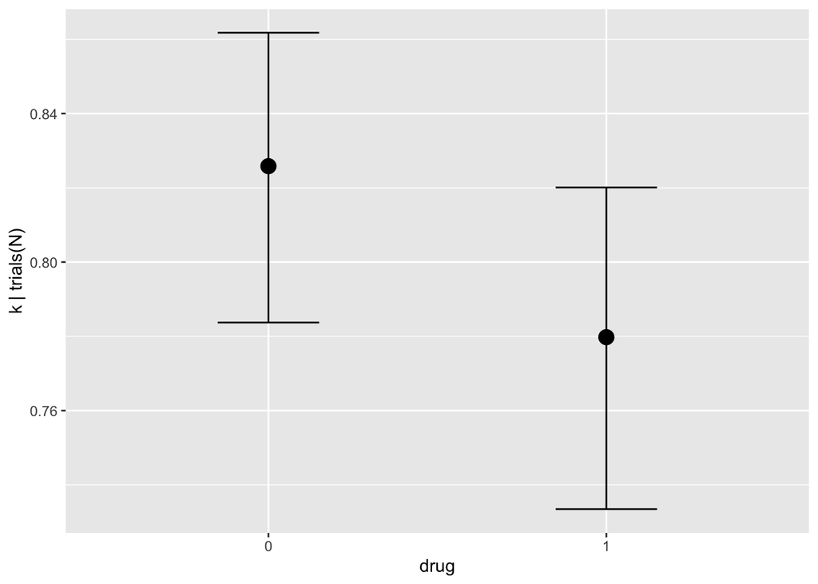

```r
conditional_effects(m_d1.1)
```

Now lets generate the expected number of survived patients under both scenarios (per 100 patients, as specified by us).

```r
newdata <- data.frame(drug= c("0", "1"), N=c(100, 100))
fitted(m_d1.1, newdata = newdata)
```

```
##      Estimate Est.Error     Q2.5    Q97.5
## [1,] 82.53977  2.015927 78.37250 86.17784
## [2,] 77.91857  2.223861 73.34701 82.01001
```

Next, lets predict for the 4000 rows of the posterior table, first in logit scale, then transform into Pr scale, then summarizing into mean and 95% CI. For each of these 4000 rows we make a counterfactual prediction that drug is either “0” or “1”. posterior_linpred() predicts in the logit scale, so we need to use inv_logit_scaled() to back-tranform into probability scale.

```r
m_d1.1 %>% posterior_linpred(newdata = newdata) %>%

  inv_logit_scaled() %>%  posterior_summary()
```

```
##       Estimate  Est.Error      Q2.5     Q97.5
## [1,] 0.8253977 0.02015927 0.7837250 0.8617784
## [2,] 0.7791857 0.02223861 0.7334701 0.8201001
```

using posterior_epred() we make our predictions directly in the metric of surviving patients per 100 people who take the drug or placebo. We still make 4000 predictions for each condition and then summarize these as before.

```r
m_d1.1 %>% posterior_epred(newdata = data.frame(drug= c("0", "1"), N=c(100, 100))) %>%
  posterior_summary()
```

```
##      Estimate Est.Error     Q2.5    Q97.5
## [1,] 82.53977  2.015927 78.37250 86.17784
## [2,] 77.91857  2.223861 73.34701 82.01001
```

Now lets extract posterior samples from the fitted model and use these to interpret the model coefficients.

```r
m_post <- as_draws_df(m_d1.1)
m_post$b_Intercept %>% inv_logit_scaled() %>% posterior_summary()
```

```
##       Estimate  Est.Error     Q2.5     Q97.5
## [1,] 0.8253977 0.02015927 0.783725 0.8617784
```

This is the intercept in probability scale - the survival rate when drug = 0.

```r
 inv_logit_scaled(m_post$b_drug1 + m_post$b_Intercept) %>% posterior_summary()
```

```
##       Estimate  Est.Error      Q2.5     Q97.5
## [1,] 0.7791857 0.02223861 0.7334701 0.8201001
```

This is the intercept + slope in probability scale - the survival rate when drug = 1.

```r
exp(m_post$b_drug1) %>% posterior_summary()
```

```
##       Estimate Est.Error     Q2.5    Q97.5
## [1,] 0.7586338 0.1449302 0.514383 1.079831
```

```r
mean(m_post$b_drug1>0)
```

```
## [1] 0.05625
```

The probability that the drug effect is actually positive is about 0.06 (this is a Bayesian p value).

And this is the effect size in percentage points with 95% CI.

```r
a <- inv_logit_scaled(m_post$b_drug1 + m_post$b_Intercept) - inv_logit_scaled(m_post$b_Intercept)
posterior_summary(a)
```

```
##         Estimate  Est.Error       Q2.5      Q97.5
## [1,] -0.04621202 0.02968225 -0.1047609 0.01208628
```

Again, we can get the same Bayesian p value as before:

```r
mean(a>0)
```

```
## [1] 0.05625
```

For our second example we model a continuous predictor, age, to see how getting postacute physical therapy depends on patients age in Estonia.

```r
HF_data <- read_delim("data/HF_data.csv",
    delim = ";", escape_double = FALSE, trim_ws = TRUE)
m_HF_binom1 <- brm(postacute_therapy_binned~age,
                   data=HF_data,
                   family = bernoulli(),
                   chains = 1,
                   file = "models/m_HF_binom1")

conditional_effects(m_HF_binom1)
```

```
## Ignoring unknown labels:
## • fill : "NA"
## • colour : "NA"
## Ignoring unknown labels:
## • fill : "NA"
## • colour : "NA"
```

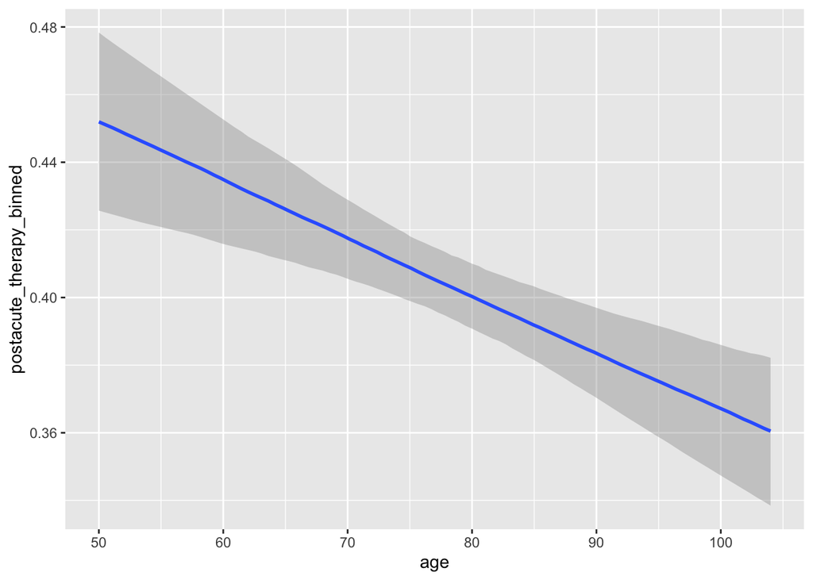

There is a clear dependence on age: older patients are considerably less likely to get the therapy they need. Altough, even the younger ones are more likely than not to get no physical therapy after hip fracture!

Next we plot this prediction together with individual data points (we use jitter to better visualize otherwise ovelapping data - each patient has either a 0 or 1 as his/her therapy status).

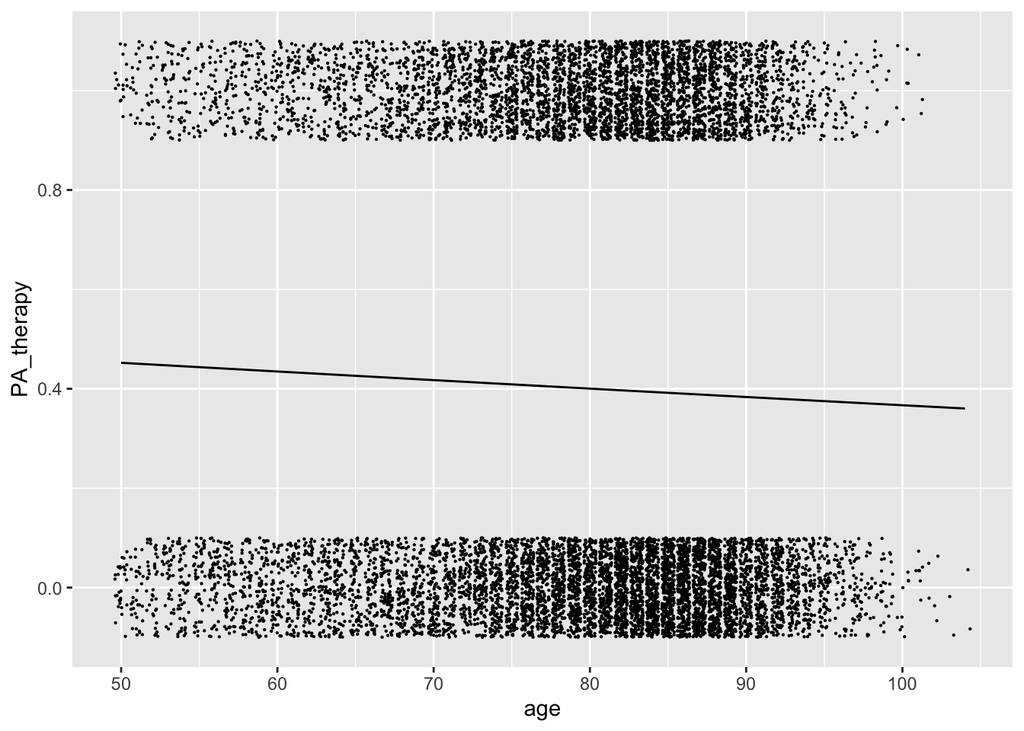

```r
HF_data <- HF_data %>% mutate(PA_therapy = case_when(postacute_therapy_binned=="Yes"~1,
                                                     TRUE ~0))

newx <- expand.grid(age = modelr::seq_range(HF_data$age,
                                            n = 100))

aa2 <- fitted(m_HF_binom1, newdata = newx) %>% cbind(newx, .)

ggplot(data = aa2, aes(x = age, y = Estimate)) +
  geom_jitter(data = HF_data, aes(age, PA_therapy), height = 0.1, size=0.1) +
  geom_line()
```

And finally a more serious model, where we add as predictors a bunch of variables, which we think might also influence people getting therapy. We intend this as a model with more predictive power, if not a causally relevant model.

```r
m_HF_binom2 <- brm(postacute_therapy_binned~age + year + survived_PAC + sex + county + comorbidity + management_method + acute_LOS + postacute_LOS,
                   data=HF_data,
                   family = bernoulli(),
                   chains = 1,
                   file = "models/m_HF_binom2")

xx <- data.frame(county =make_conditions(HF_data, "county"), row.names = unique(HF_data$county))

conditional_effects(m_HF_binom2, effects = "management_method",
                    conditions = xx)
```

```
## Ignoring unknown labels:
## • fill : "NA"
## • colour : "NA"
## Ignoring unknown labels:
## • fill : "NA"
## • colour : "NA"
```

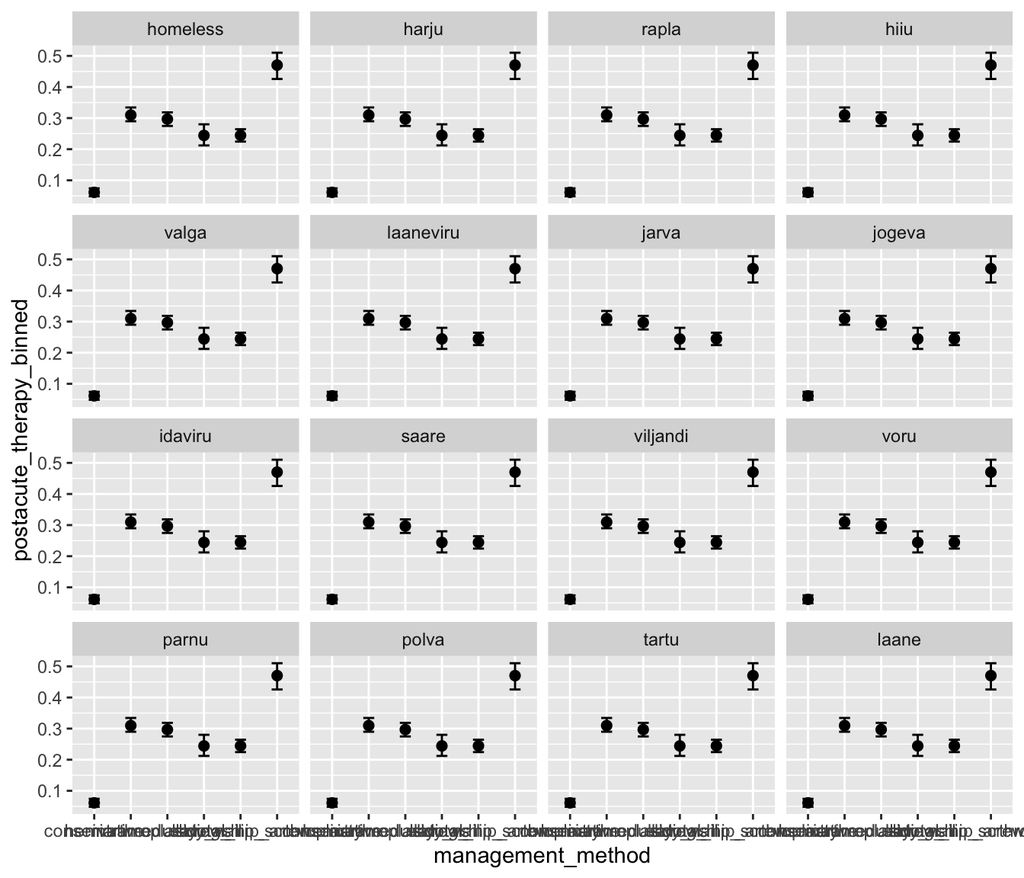

```r
conditional_effects(m_HF_binom2, effects = "county")
```

```
## Ignoring unknown labels:
## • fill : "NA"
## • colour : "NA"
## Ignoring unknown labels:
## • fill : "NA"
## • colour : "NA"
```

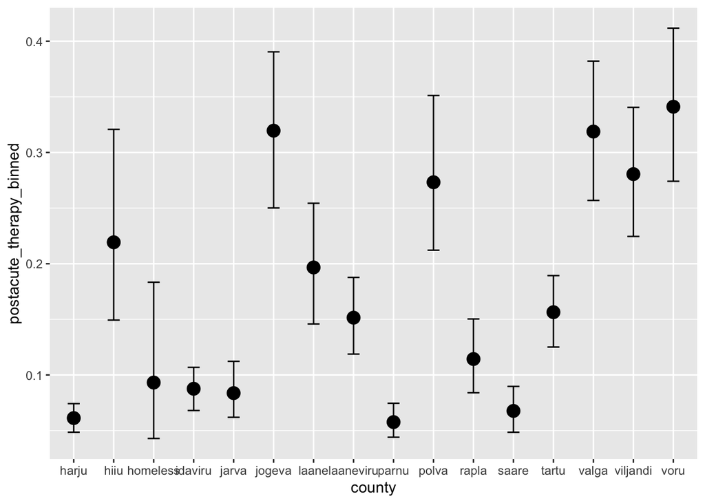

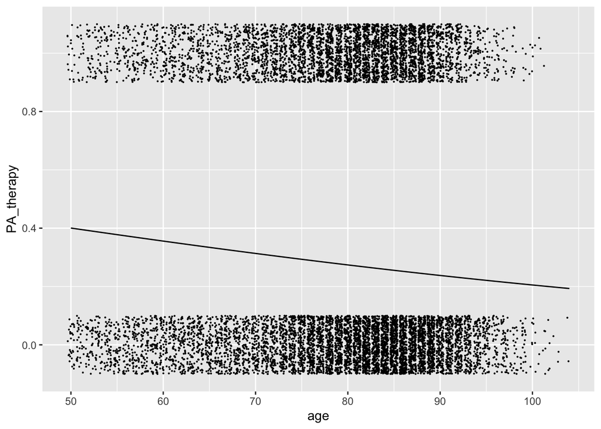

```r
HF_data <- HF_data %>% mutate(PA_therapy = case_when(postacute_therapy_binned=="Yes"~1,
                                                     TRUE ~0))

newx <- expand.grid(age = modelr::seq_range(HF_data$age, n = 100),
                    year = 2016,
                    survived_PAC = 1,
                    sex="f",
                    county = "harju",
                    comorbidity = 0,
                    management_method = "hemiarthroplasty",
                    acute_LOS = 10,
                    postacute_LOS=1)

aa4 <- fitted(m_HF_binom2, newdata = newx) %>% cbind(newx, .)

ggplot(data = aa4, aes(x = age, y = Estimate)) +

  geom_jitter(data = HF_data, aes(age, PA_therapy), height = 0.1, size=0.1) +

  geom_line()
```